# **1. Perkenalan Dataset**

Dataset yang digunakan dalam proyek clustering ini terdiri dari **16 fitur** dan tidak memiliki label atau kolom target, sehingga cocok untuk pendekatan **unsupervised learning**. Data ini menggambarkan berbagai informasi terkait transaksi akun pengguna, yang melibatkan elemen waktu, lokasi, perilaku transaksi, dan atribut pengguna. Dataset ini saya peroleh dari [Kaggle](https://www.kaggle.com/datasets/valakhorasani/bank-transaction-dataset-for-fraud-detection)

Berikut adalah deskripsi ringkas dari masing-masing fitur dalam dataset:

1. TransactionID: identitas unik untuk tiap transaksi
2. AccountID: identitas unik untuk tiap akun, yang mana satu akun bisa lebih dari satu kali transaksi.
3. TransactionAmount: nilai monetary tiap transaksi. Rangenya dari pengeluaran terkecil sehari-hari hingga pengeluaran besar.
4. TransactionDate: waktu di mana setiap transaksi terlaksana, ada tanggal dan jamnya.
5. TransactionType: kategori yang menunjukkan transaksi kredit atau debit.
6. Location: lokasi geografis transaksi terlaksana, yang mana pada data ini semuanya adalah nama kota di U.S.
7. DeviceID: identitas untuk perangkat yang digunakan user dalam bertransaksi.
8. IP Address: Alamat IPv4 yang terkait dengan transaksi, ada **perubahan sesekali untuk beberapa akun**.
9. MerchantID: identitas untik untuk tiap merchant atau pedagang,**yang menunjukkan pedagang yang disukai dan yang tidak disukai untuk setiap akun**.
10. AccountBalance: Saldo di akun pengguna setelah transaksi,**yang berkolerasi dengan Transaction type dan Transaction amount**.
11. PreviousTransactionDate: Waktu akun melakukan transaksi, menghitung frekuensi transaksi.
12. Channel: Jenis channel yang digunakan untuk bertransaksi, bisa melalui ATM, Mobile, Online, atau Branch.
13. CustomerAge: Umur pengguna akun, dengan pengelompokkan berdasarkan pekerjaan.
14. CustomerOccupation: Pekerjaan pemegang akun yang **mencerminkan pendapatan**.
15. TransactionDuration: Durasi transaksi dalam detik, **bervariasi menurut jenis transaksi**.
16. LoginAttempts: Jumlah percobaan login sebelum transaksi, dengan **nilai yang lebih tinggi mengindikasikan potensi anomali** atau kecurigaan.

# **2. Import Library**

Pada tahap ini, Anda perlu mengimpor beberapa pustaka (library) Python yang dibutuhkan untuk analisis data dan pembangunan model machine learning.

```python
# General libraries
import pandas as pd
import numpy as np
import matplotlib.pyplot as plt
import seaborn as sns
import missingno as msno

# Sklearn modules
from sklearn.preprocessing import StandardScaler
from sklearn.metrics import silhouette_score
from sklearn.decomposition import PCA
from sklearn.cluster import KMeans

# Visualisasi clustering
from yellowbrick.cluster import KElbowVisualizer

# Elbow detection
from kneed import KneeLocator
```

# **3. Memuat Dataset**

Pada tahap ini, Anda perlu memuat dataset ke dalam notebook. Jika dataset dalam format CSV, Anda bisa menggunakan pustaka pandas untuk membacanya. Pastikan untuk mengecek beberapa baris awal dataset untuk memahami strukturnya dan memastikan data telah dimuat dengan benar.

Jika dataset berada di Google Drive, pastikan Anda menghubungkan Google Drive ke Colab terlebih dahulu. Setelah dataset berhasil dimuat, langkah berikutnya adalah memeriksa kesesuaian data dan siap untuk dianalisis lebih lanjut.

```python
# Memuat dataset csv
df = pd.read_csv('Dataset_clustering.csv')
df
```

|  | TransactionID | AccountID | TransactionAmount | TransactionDate | TransactionType | Location | DeviceID | IP Address | MerchantID | Channel | CustomerAge | CustomerOccupation | TransactionDuration | LoginAttempts | AccountBalance | PreviousTransactionDate |
| --- | --- | --- | --- | --- | --- | --- | --- | --- | --- | --- | --- | --- | --- | --- | --- | --- |
| 0 | TX000001 | AC00128 | 14.09 | 2023-04-11 16:29:14 | Debit | San Diego | D000380 | 162.198.218.92 | M015 | ATM | 70 | Doctor | 81 | 1 | 5112.21 | 2024-11-04 08:08:08 |
| 1 | TX000002 | AC00455 | 376.24 | 2023-06-27 16:44:19 | Debit | Houston | D000051 | 13.149.61.4 | M052 | ATM | 68 | Doctor | 141 | 1 | 13758.91 | 2024-11-04 08:09:35 |
| 2 | TX000003 | AC00019 | 126.29 | 2023-07-10 18:16:08 | Debit | Mesa | D000235 | 215.97.143.157 | M009 | Online | 19 | Student | 56 | 1 | 1122.35 | 2024-11-04 08:07:04 |
| 3 | TX000004 | AC00070 | 184.50 | 2023-05-05 16:32:11 | Debit | Raleigh | D000187 | 200.13.225.150 | M002 | Online | 26 | Student | 25 | 1 | 8569.06 | 2024-11-04 08:09:06 |
| 4 | TX000005 | AC00411 | 13.45 | 2023-10-16 17:51:24 | Credit | Atlanta | D000308 | 65.164.3.100 | M091 | Online | 26 | Student | 198 | 1 | 7429.40 | 2024-11-04 08:06:39 |
| ... | ... | ... | ... | ... | ... | ... | ... | ... | ... | ... | ... | ... | ... | ... | ... | ... |
| 2507 | TX002508 | AC00297 | 856.21 | 2023-04-26 17:09:36 | Credit | Colorado Springs | D000625 | 21.157.41.17 | M072 | Branch | 33 | Doctor | 109 | 1 | 12690.79 | 2024-11-04 08:11:29 |
| 2508 | TX002509 | AC00322 | 251.54 | 2023-03-22 17:36:48 | Debit | Tucson | D000410 | 49.174.157.140 | M029 | Branch | 48 | Doctor | 177 | 1 | 254.75 | 2024-11-04 08:11:42 |
| 2509 | TX002510 | AC00095 | 28.63 | 2023-08-21 17:08:50 | Debit | San Diego | D000095 | 58.1.27.124 | M087 | Branch | 56 | Retired | 146 | 1 | 3382.91 | 2024-11-04 08:08:39 |
| 2510 | TX002511 | AC00118 | 185.97 | 2023-02-24 16:24:46 | Debit | Denver | D000634 | 21.190.11.223 | M041 | Online | 23 | Student | 19 | 1 | 1776.91 | 2024-11-04 08:12:22 |
| 2511 | TX002512 | AC00009 | 243.08 | 2023-02-14 16:21:23 | Credit | Jacksonville | D000215 | 59.127.135.25 | M041 | Online | 24 | Student | 93 | 1 | 131.25 | 2024-11-04 08:07:49 |

2512 rows × 16 columns

# **4. Exploratory Data Analysis (EDA)**

Pada tahap ini, Anda akan melakukan **Exploratory Data Analysis (EDA)** untuk memahami karakteristik dataset. EDA bertujuan untuk:

1. **Memahami Struktur Data**
   - Tinjau jumlah baris dan kolom dalam dataset.
   - Tinjau jenis data di setiap kolom (numerikal atau kategorikal).
2. **Menangani Data yang Hilang**
   - Identifikasi dan analisis data yang hilang (*missing values*). Tentukan langkah-langkah yang diperlukan untuk menangani data yang hilang, seperti pengisian atau penghapusan data tersebut.
3. **Analisis Distribusi dan Korelasi**
   - Analisis distribusi variabel numerik dengan statistik deskriptif dan visualisasi seperti histogram atau boxplot.
   - Periksa hubungan antara variabel menggunakan matriks korelasi atau scatter plot.
4. **Visualisasi Data**
   - Buat visualisasi dasar seperti grafik distribusi dan diagram batang untuk variabel kategorikal.
   - Gunakan heatmap atau pairplot untuk menganalisis korelasi antar variabel.

Tujuan dari EDA adalah untuk memperoleh wawasan awal yang mendalam mengenai data dan menentukan langkah selanjutnya dalam analisis atau pemodelan.

```python
df.describe()
```

|  | TransactionAmount | CustomerAge | TransactionDuration | LoginAttempts | AccountBalance |
| --- | --- | --- | --- | --- | --- |
| count | 2512.000000 | 2512.000000 | 2512.000000 | 2512.000000 | 2512.000000 |
| mean | 297.593778 | 44.673965 | 119.643312 | 1.124602 | 5114.302966 |
| std | 291.946243 | 17.792198 | 69.963757 | 0.602662 | 3900.942499 |
| min | 0.260000 | 18.000000 | 10.000000 | 1.000000 | 101.250000 |
| 25% | 81.885000 | 27.000000 | 63.000000 | 1.000000 | 1504.370000 |
| 50% | 211.140000 | 45.000000 | 112.500000 | 1.000000 | 4735.510000 |
| 75% | 414.527500 | 59.000000 | 161.000000 | 1.000000 | 7678.820000 |
| max | 1919.110000 | 80.000000 | 300.000000 | 5.000000 | 14977.990000 |

Data ini memiliki 2512 baris transaksi unik dan 16 kolom yang berisi informasi tentang transaksi.

```python
print(df.dtypes)
```

```
TransactionID               object
AccountID                   object
TransactionAmount          float64
TransactionDate             object
TransactionType             object
Location                    object
DeviceID                    object
IP Address                  object
MerchantID                  object
Channel                     object
CustomerAge                  int64
CustomerOccupation          object
TransactionDuration          int64
LoginAttempts                int64
AccountBalance             float64
PreviousTransactionDate     object
dtype: object
```

```python
df.head()
```

|  | TransactionID | AccountID | TransactionAmount | TransactionDate | TransactionType | Location | DeviceID | IP Address | MerchantID | Channel | CustomerAge | CustomerOccupation | TransactionDuration | LoginAttempts | AccountBalance | PreviousTransactionDate |
| --- | --- | --- | --- | --- | --- | --- | --- | --- | --- | --- | --- | --- | --- | --- | --- | --- |
| 0 | TX000001 | AC00128 | 14.09 | 2023-04-11 16:29:14 | Debit | San Diego | D000380 | 162.198.218.92 | M015 | ATM | 70 | Doctor | 81 | 1 | 5112.21 | 2024-11-04 08:08:08 |
| 1 | TX000002 | AC00455 | 376.24 | 2023-06-27 16:44:19 | Debit | Houston | D000051 | 13.149.61.4 | M052 | ATM | 68 | Doctor | 141 | 1 | 13758.91 | 2024-11-04 08:09:35 |
| 2 | TX000003 | AC00019 | 126.29 | 2023-07-10 18:16:08 | Debit | Mesa | D000235 | 215.97.143.157 | M009 | Online | 19 | Student | 56 | 1 | 1122.35 | 2024-11-04 08:07:04 |
| 3 | TX000004 | AC00070 | 184.50 | 2023-05-05 16:32:11 | Debit | Raleigh | D000187 | 200.13.225.150 | M002 | Online | 26 | Student | 25 | 1 | 8569.06 | 2024-11-04 08:09:06 |
| 4 | TX000005 | AC00411 | 13.45 | 2023-10-16 17:51:24 | Credit | Atlanta | D000308 | 65.164.3.100 | M091 | Online | 26 | Student | 198 | 1 | 7429.40 | 2024-11-04 08:06:39 |

Dari 16 variabel atau kolom pada dataset ini, terdapat dua jenis variabel, yakni kategorik dan numerik.

[output not shown]

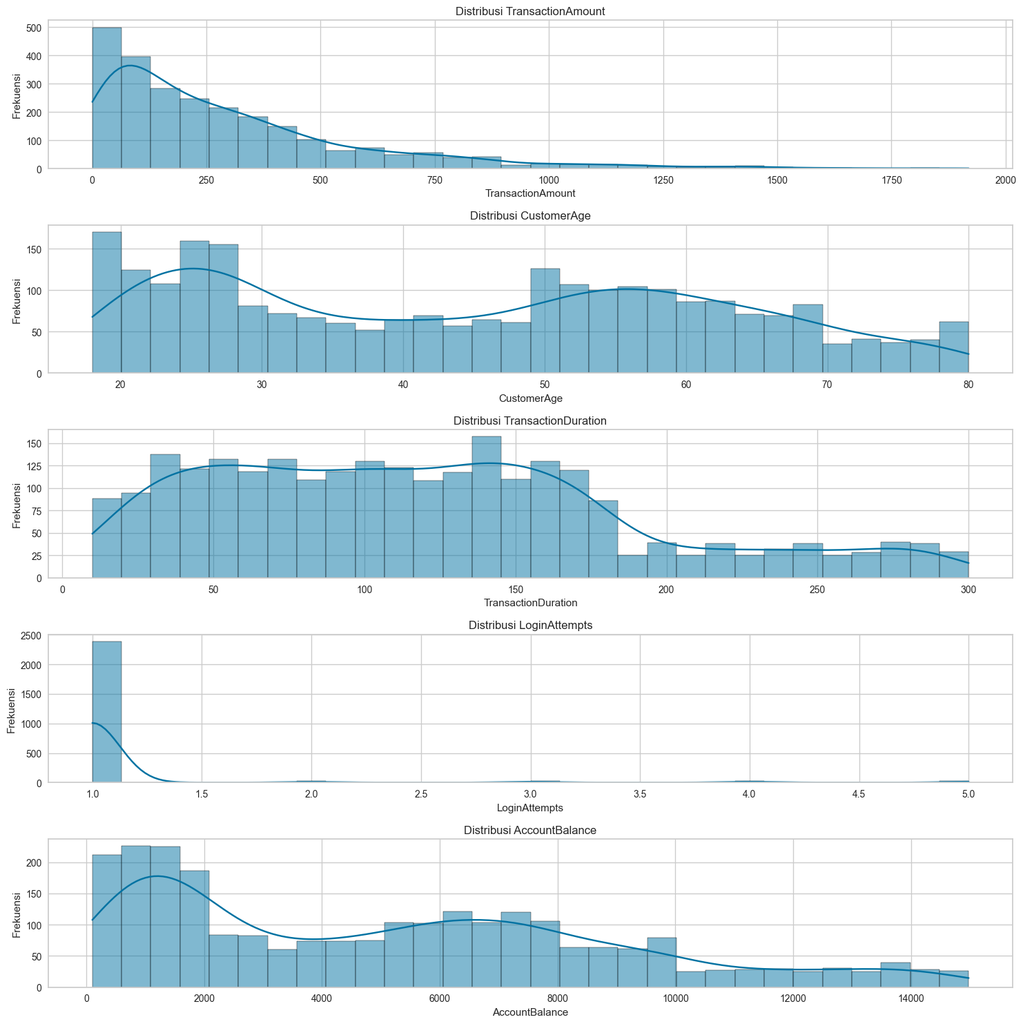

```python
# Menentukan kolom numerik secara manual
numerical_columns = ['TransactionAmount', 'CustomerAge', 'TransactionDuration', 'LoginAttempts', 'AccountBalance']

plt.figure(figsize=(15, 3 * len(numerical_columns)))

for i, col in enumerate(numerical_columns, 1):
    plt.subplot(len(numerical_columns), 1, i)
    sns.histplot(data=df, x=col, kde=True, bins=30, palette='viridis')
    plt.title(f'Distribusi {col}')
    plt.xlabel(col)
    plt.ylabel('Frekuensi')

plt.tight_layout()
plt.show()
```

```python
# Print nunique value sort from largest
print(df.nunique().sort_values(ascending=False))
```

```
TransactionID              2512
TransactionDate            2512
AccountBalance             2510
TransactionAmount          2455
DeviceID                    681
IP Address                  592
AccountID                   495
PreviousTransactionDate     360
TransactionDuration         288
MerchantID                  100
CustomerAge                  63
Location                     43
LoginAttempts                 5
CustomerOccupation            4
Channel                       3
TransactionType               2
dtype: int64
```

[output not shown]

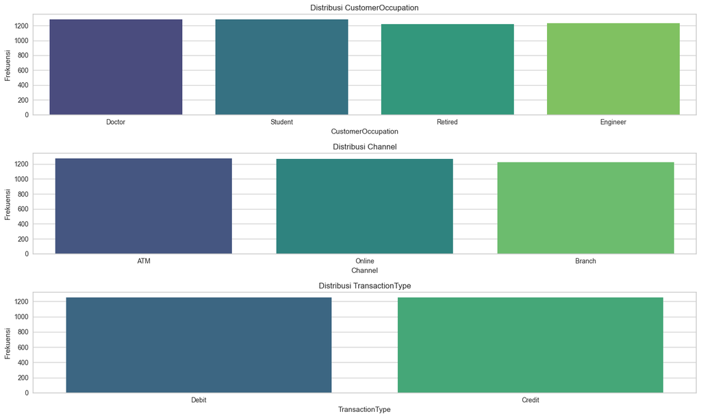

```python
# Menentukan kolom kategori secara manual
categorical_columns = [ 'CustomerOccupation', 'Channel', 'TransactionType']

plt.figure(figsize=(15, 3 * len(categorical_columns)))

for i, col in enumerate(categorical_columns, 1):
    plt.subplot(len(categorical_columns), 1, i)
    sns.barplot(data=df, x=col, y=df.index, palette='viridis', ci=None)
    plt.title(f'Distribusi {col}')
    plt.xlabel(col)
    plt.ylabel('Frekuensi')

plt.tight_layout()
plt.show()
```

Distribusi kategori menunjukkan bahwa jumlah data di setiap kategori relatif seimbang tanpa perbedaan signifikan antar kelompok.

```python
# print unique value dan jumlah unique value dari df['Location']
print(df['Location'].value_counts())
```

```
Location
Fort Worth          70
Los Angeles         69
Oklahoma City       68
Charlotte           68
Tucson              67
Philadelphia        67
Omaha               65
Miami               64
Detroit             63
Houston             63
Memphis             63
Denver              62
Kansas City         61
Boston              61
Mesa                61
Atlanta             61
Seattle             61
Colorado Springs    60
Jacksonville        60
Fresno              60
Chicago             60
Austin              59
San Jose            59
Raleigh             59
San Antonio         59
San Diego           59
Indianapolis        58
New York            58
San Francisco       57
Nashville           55
Milwaukee           55
Las Vegas           55
Virginia Beach      55
Phoenix             55
Columbus            54
Sacramento          53
Baltimore           51
Louisville          51
Dallas              49
Washington          48
El Paso             46
Portland            42
Albuquerque         41
Name: count, dtype: int64
```

```python
df.isnull().sum()
```

```
TransactionID              0
AccountID                  0
TransactionAmount          0
TransactionDate            0
TransactionType            0
Location                   0
DeviceID                   0
IP Address                 0
MerchantID                 0
Channel                    0
CustomerAge                0
CustomerOccupation         0
TransactionDuration        0
LoginAttempts              0
AccountBalance             0
PreviousTransactionDate    0
dtype: int64
```

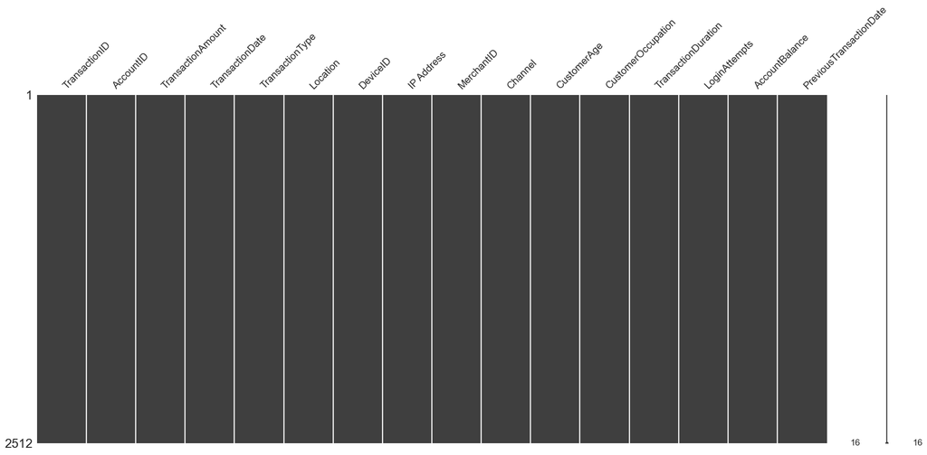

```python
# Atur ukuran figure lebih kecil
plt.figure(figsize=(1, 1))  # Sesuaikan width dan height sesuai kebutuhan
msno.matrix(df)
plt.show()
```

Tidak ada missing value pada data, artinya tidak perlu ada penanganan data yang hilang.

```python
# Cek jumlah baris duplikat
duplicate_rows = df.duplicated().sum()
print(f"Jumlah baris duplikat: {duplicate_rows}")
```

```
Jumlah baris duplikat: 0
```

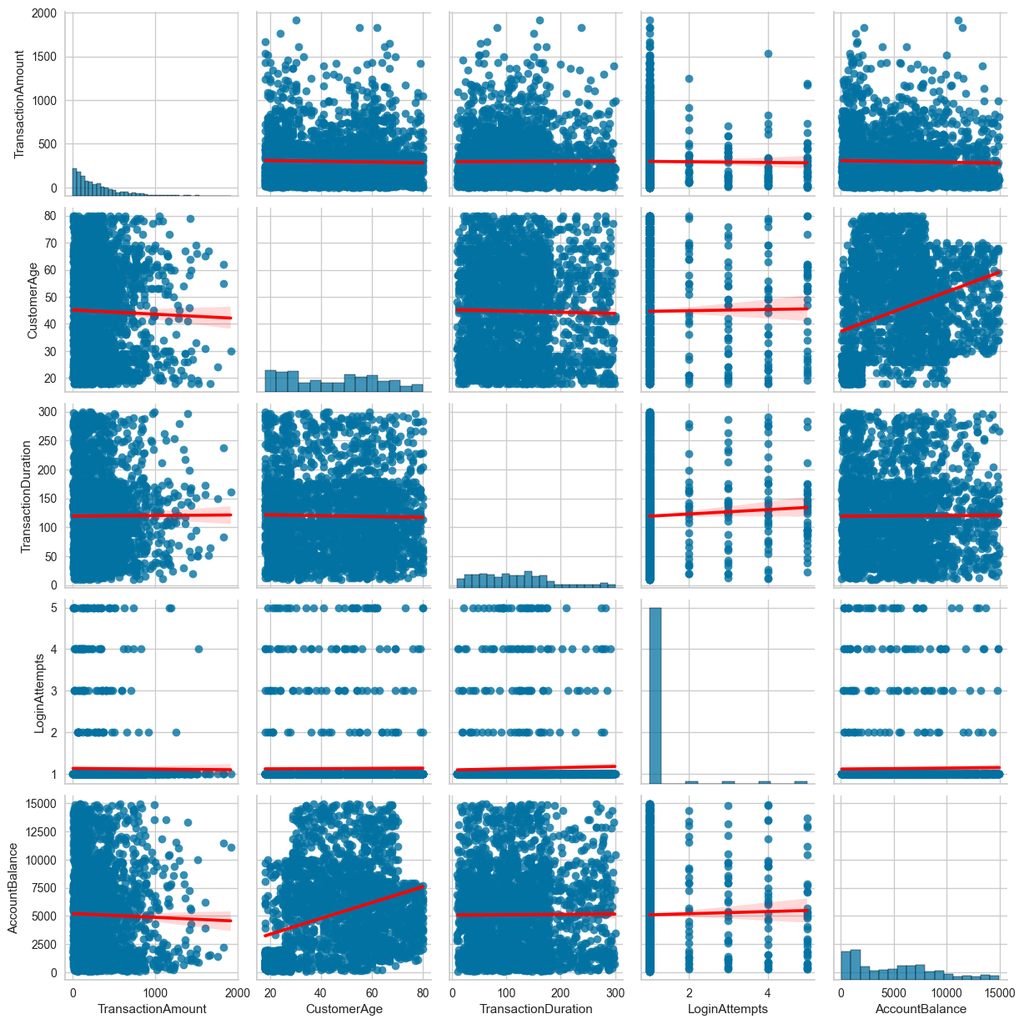

```python
# Pilih hanya kolom numerik
numerical_columns = df.select_dtypes(include=['number']).columns

# Buat scatter plot dengan garis regresi berwarna merah
sns.pairplot(df[numerical_columns], kind="reg", plot_kws={"line_kws":{"color":"red"}})

plt.show()
```

Garis regresi merah hampir datar pada banyak grafik, menunjukkan korelasi yang sangat lemah atau tidak ada hubungan. Sebagian besar pasangan variabel numerik menunjukkan distribusi yang tersebar tanpa pola linear yang jelas.

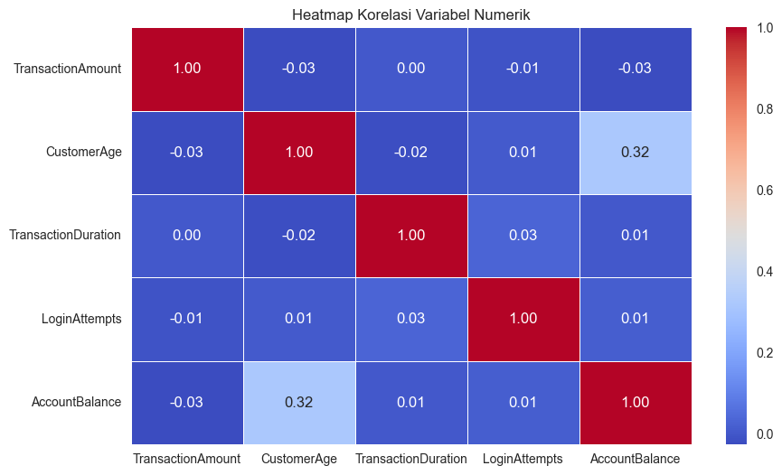

```python
# Pilih hanya kolom numerik
df_numeric = df.select_dtypes(include=[float, int])

# Hitung matriks korelasi untuk variabel numerik
correlation_matrix = df_numeric.corr()

# Buat heatmap korelasi
plt.figure(figsize=(10, 6))
sns.heatmap(correlation_matrix, annot=True, cmap="coolwarm", fmt=".2f", linewidths=0.5)

plt.title("Heatmap Korelasi Variabel Numerik")
plt.show()
```

Customer Age atau umur customer memiliki korelasi positif tapi tidak kuat dengan Account Balance atau saldo akun. Semakin tua umur customer, maka saldo akun cenderung lebih tinggi. Variabel lainnya tidak memiliki korelasi yang signifikan secara statistik.

# **5. Data Preprocessing**

Pada tahap ini, data preprocessing adalah langkah penting untuk memastikan kualitas data sebelum digunakan dalam model machine learning. Data mentah sering kali mengandung nilai kosong, duplikasi, atau rentang nilai yang tidak konsisten, yang dapat memengaruhi kinerja model. Oleh karena itu, proses ini bertujuan untuk membersihkan dan mempersiapkan data agar analisis berjalan optimal.

Berikut adalah tahapan-tahapan yang bisa dilakukan, tetapi **tidak terbatas** pada:

1. Menghapus atau Menangani Data Kosong (Missing Values)
2. Menghapus Data Duplikat
3. Normalisasi atau Standarisasi Fitur
4. Deteksi dan Penanganan Outlier
5. Encoding Data Kategorikal
6. Binning (Pengelompokan Data)

Cukup sesuaikan dengan karakteristik data yang kamu gunakan yah.

1. Cek Missing dan duplikasi data

```python
# cek duplikasi
duplicate_rows = df.duplicated().sum()
print(f"Jumlah baris duplikat: {duplicate_rows}")
# cek missing value
missing_values = df.isnull().sum()
print(f"Jumlah missing value:\n{missing_values}")
```

```
Jumlah baris duplikat: 0
Jumlah missing value:
TransactionID              0
AccountID                  0
TransactionAmount          0
TransactionDate            0
TransactionType            0
Location                   0
DeviceID                   0
IP Address                 0
MerchantID                 0
Channel                    0
CustomerAge                0
CustomerOccupation         0
TransactionDuration        0
LoginAttempts              0
AccountBalance             0
PreviousTransactionDate    0
dtype: int64
```

2. Deteksi Outlier

[output not shown]

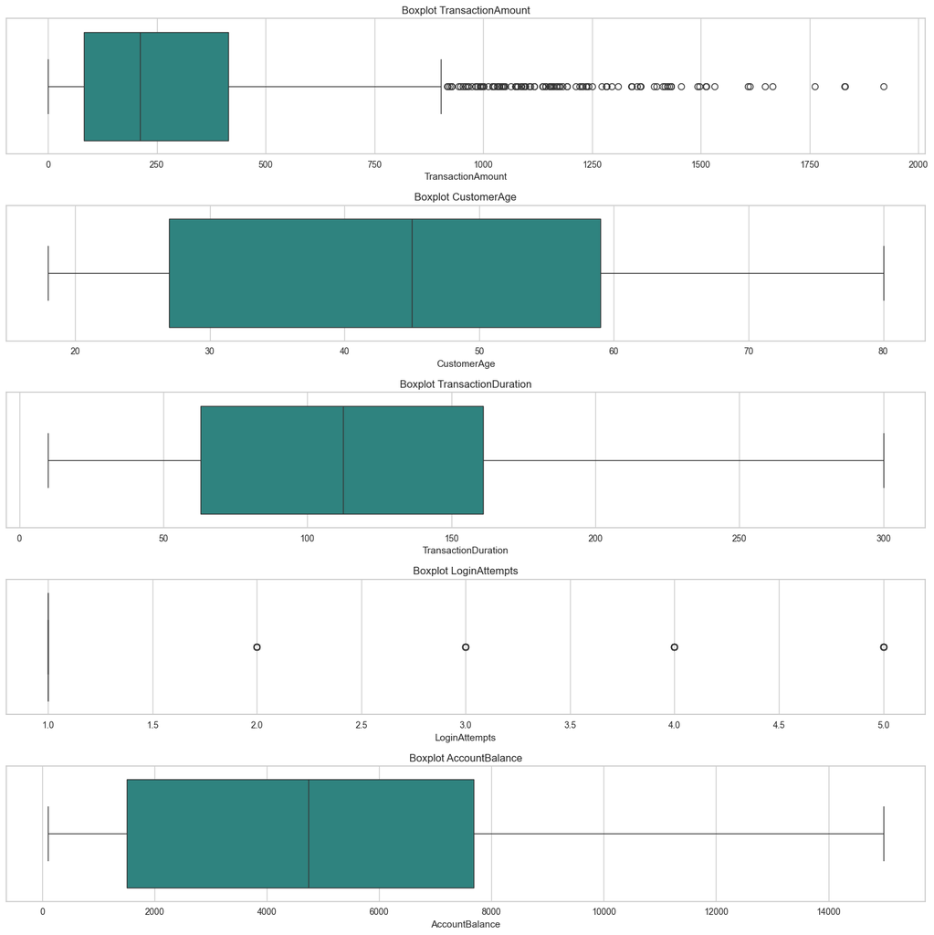

```python
# deteksi outlier, select numeric first
numerical_columns = df.select_dtypes(include=['number']).columns
# buat boxplot untuk setiap kolom numerik
plt.figure(figsize=(15, 3 * len(numerical_columns)))
for i, col in enumerate(numerical_columns, 1):
    plt.subplot(len(numerical_columns), 1, i)
    sns.boxplot(x=df[col], palette='viridis')
    plt.title(f'Boxplot {col}')
    plt.xlabel(col)
plt.tight_layout()
plt.show()
```

Dari boxplot di atas, nampak bahwa variabel TransactionAmount memiliki outlie yang cukup banyak. Oleh karena itu, ini perlu ditangani selanjutnya. Penanganan yang dilakukan adalah standardisasi data menggunakan metode standard scaler.

```python
# buat df_clust dengan drop kolom tidak relevan
df_clust = df.drop(['TransactionID','TransactionDate','Location' ,'AccountID','DeviceID','IP Address','MerchantID','PreviousTransactionDate','CustomerOccupation'], axis=1)
df_clust
```

|  | TransactionAmount | TransactionType | Channel | CustomerAge | TransactionDuration | LoginAttempts | AccountBalance |
| --- | --- | --- | --- | --- | --- | --- | --- |
| 0 | 14.09 | Debit | ATM | 70 | 81 | 1 | 5112.21 |
| 1 | 376.24 | Debit | ATM | 68 | 141 | 1 | 13758.91 |
| 2 | 126.29 | Debit | Online | 19 | 56 | 1 | 1122.35 |
| 3 | 184.50 | Debit | Online | 26 | 25 | 1 | 8569.06 |
| 4 | 13.45 | Credit | Online | 26 | 198 | 1 | 7429.40 |
| ... | ... | ... | ... | ... | ... | ... | ... |
| 2507 | 856.21 | Credit | Branch | 33 | 109 | 1 | 12690.79 |
| 2508 | 251.54 | Debit | Branch | 48 | 177 | 1 | 254.75 |
| 2509 | 28.63 | Debit | Branch | 56 | 146 | 1 | 3382.91 |
| 2510 | 185.97 | Debit | Online | 23 | 19 | 1 | 1776.91 |
| 2511 | 243.08 | Credit | Online | 24 | 93 | 1 | 131.25 |

2512 rows × 7 columns

Melakukan One Hot Encoding pada variabel kategorikal, yaitu TransactionType dan Channel.

```python
# Melakukan One-Hot Encoding
df_encoded = pd.get_dummies(df_clust)
df_encoded
```

|  | TransactionAmount | CustomerAge | TransactionDuration | LoginAttempts | AccountBalance | TransactionType_Credit | TransactionType_Debit | Channel_ATM | Channel_Branch | Channel_Online |
| --- | --- | --- | --- | --- | --- | --- | --- | --- | --- | --- |
| 0 | 14.09 | 70 | 81 | 1 | 5112.21 | False | True | True | False | False |
| 1 | 376.24 | 68 | 141 | 1 | 13758.91 | False | True | True | False | False |
| 2 | 126.29 | 19 | 56 | 1 | 1122.35 | False | True | False | False | True |
| 3 | 184.50 | 26 | 25 | 1 | 8569.06 | False | True | False | False | True |
| 4 | 13.45 | 26 | 198 | 1 | 7429.40 | True | False | False | False | True |
| ... | ... | ... | ... | ... | ... | ... | ... | ... | ... | ... |
| 2507 | 856.21 | 33 | 109 | 1 | 12690.79 | True | False | False | True | False |
| 2508 | 251.54 | 48 | 177 | 1 | 254.75 | False | True | False | True | False |
| 2509 | 28.63 | 56 | 146 | 1 | 3382.91 | False | True | False | True | False |
| 2510 | 185.97 | 23 | 19 | 1 | 1776.91 | False | True | False | False | True |
| 2511 | 243.08 | 24 | 93 | 1 | 131.25 | True | False | False | False | True |

2512 rows × 10 columns

Melakukan standarisasi data numerik menggunakan StandardScaler.

```python
# Misalkan df_encoded adalah DataFrame Anda
scaler = StandardScaler()

# Menerapkan standard scaler pada DataFrame
scaled_data = scaler.fit_transform(df_encoded)

# Jika ingin mengubahnya kembali menjadi DataFrame
scaled_df_encoded = pd.DataFrame(scaled_data, columns=df_encoded.columns)
scaled_df_encoded
```

|  | TransactionAmount | CustomerAge | TransactionDuration | LoginAttempts | AccountBalance | TransactionType_Credit | TransactionType_Debit | Channel_ATM | Channel_Branch | Channel_Online |
| --- | --- | --- | --- | --- | --- | --- | --- | --- | --- | --- |
| 0 | -0.971275 | 1.423718 | -0.552443 | -0.206794 | -0.000537 | -0.540538 | 0.540538 | 1.419720 | -0.726623 | -0.690491 |
| 1 | 0.269440 | 1.311287 | 0.305314 | -0.206794 | 2.216472 | -0.540538 | 0.540538 | 1.419720 | -0.726623 | -0.690491 |
| 2 | -0.586882 | -1.443277 | -0.909842 | -0.206794 | -1.023534 | -0.540538 | 0.540538 | -0.704364 | -0.726623 | 1.448244 |
| 3 | -0.387456 | -1.049768 | -1.353017 | -0.206794 | 0.885797 | -0.540538 | 0.540538 | -0.704364 | -0.726623 | 1.448244 |
| 4 | -0.973468 | -1.049768 | 1.120184 | -0.206794 | 0.593589 | 1.850010 | -1.850010 | -0.704364 | -0.726623 | 1.448244 |
| ... | ... | ... | ... | ... | ... | ... | ... | ... | ... | ... |
| 2507 | 1.913802 | -0.656259 | -0.152156 | -0.206794 | 1.942606 | 1.850010 | -1.850010 | -0.704364 | 1.376230 | -0.690491 |
| 2508 | -0.157779 | 0.186975 | 0.819969 | -0.206794 | -1.245986 | -0.540538 | 0.540538 | -0.704364 | 1.376230 | -0.690491 |
| 2509 | -0.921462 | 0.636700 | 0.376794 | -0.206794 | -0.443928 | -0.540538 | 0.540538 | -0.704364 | 1.376230 | -0.690491 |
| 2510 | -0.382420 | -1.218415 | -1.438793 | -0.206794 | -0.855705 | -0.540538 | 0.540538 | -0.704364 | -0.726623 | 1.448244 |
| 2511 | -0.186763 | -1.162199 | -0.380892 | -0.206794 | -1.277652 | 1.850010 | -1.850010 | -0.704364 | -0.726623 | 1.448244 |

2512 rows × 10 columns

# **6. Pembangunan Model Clustering**

## **a. Pembangunan Model Clustering**

1. Algoritma clustering yang akan dipilih adalah KMeans. Algoritma ini dipilih karena cocok untuk data yang memiliki jumlah cluster yang sudah diketahui. Selain itu, algoritma ini juga cocok untuk data yang memiliki jumlah cluster yang cukup besar. K-Means dipilih karena:
- Skalabilitas yang baik terhadap dataset besar.
- Interpretasi cluster yang relatif mudah.
- Dapat dikombinasikan dengan PCA untuk efisiensi komputasi.

## **b. Evaluasi Model Clustering**

### Menentukan Jumlah Cluster Optimal (Metode Elbow)

Untuk menentukan jumlah cluster yang optimal dalam algoritma K-Means, digunakan metode Elbow. Visualisasi dilakukan menggunakan KElbowVisualizer dari library yellowbrick.

Metode ini menghitung distortion score (jumlah kuadrat jarak antar titik dan pusat klasternya) untuk berbagai nilai k (jumlah cluster), lalu mencari titik "siku" (elbow) pada grafik.

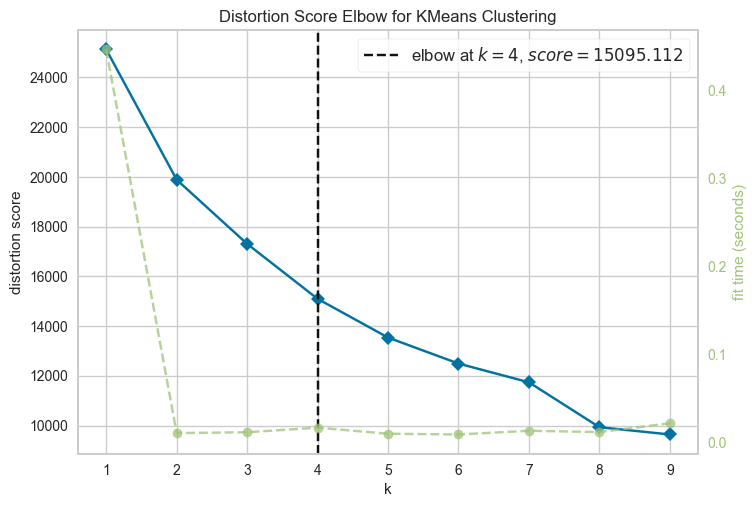

```
Jumlah cluster optimal berdasarkan metode Elbow: 4
```

```python
kmeans = KMeans(random_state=42)
visualizer = KElbowVisualizer(kmeans, k=(1, 10))
visualizer.fit(scaled_df_encoded)
visualizer.show()
plt.show()
# Menampilkan jumlah cluster optimal yang dipilih oleh KElbowVisualizer
print(f"Jumlah cluster optimal berdasarkan metode Elbow: {visualizer.elbow_value_}")
```

Berdasarkan grafik di atas, terlihat bahwa titik elbow terjadi pada k = 4, dengan nilai distortion score sebesar 15095,112.

### Menentukan Jumlah Cluster Optimal (Metode Silhouette Score)

Selain metode Elbow, jumlah cluster optimal juga dievaluasi menggunakan Silhouette Score. Metode ini mengukur seberapa baik setiap titik data berada dalam klasternya dibandingkan dengan klaster lain.

- Nilai berkisar antara -1 hingga 1.
- Nilai mendekati 1 menunjukkan bahwa data sangat cocok dengan klasternya dan sangat berbeda dari klaster lain.
- Nilai mendekati 0 menunjukkan bahwa data berada di batas antar cluster.
- Nilai negatif menandakan kemungkinan salah klasterisasi.

```
Cluster optimal Metode Silhoutte Score: 2
```

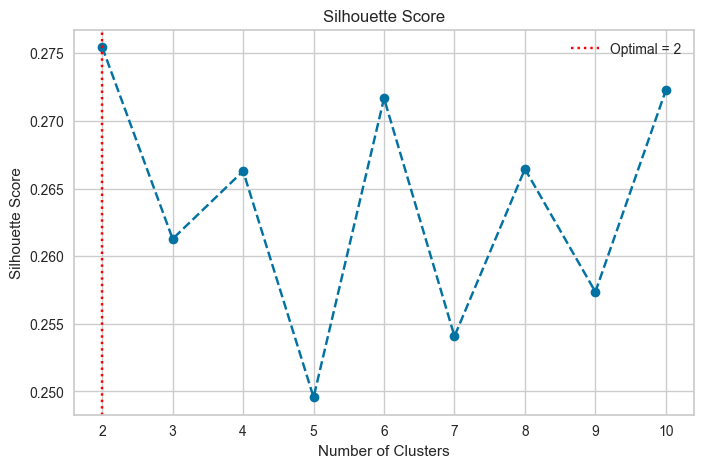

```python
# Penentuan Klaster optimal berdasarkan silhoutte score
silhouette_scores = []
for i in range(2, 11):
    kmeans = KMeans(n_clusters=i, random_state=42)
    kmeans.fit(scaled_df_encoded)
    silhouette_scores.append(silhouette_score(scaled_df_encoded, kmeans.labels_))
optimal_clusters = np.argmax(silhouette_scores) + 2  # Karena range mulai dari 2
print(f"Cluster optimal Metode Silhoutte Score: {optimal_clusters}")

# Visualisasi Silhouette Score
plt.figure(figsize=(8, 5))
plt.plot(range(2, 11), silhouette_scores, marker='o', linestyle='--')
plt.title('Silhouette Score')
plt.xlabel('Number of Clusters')
plt.ylabel('Silhouette Score')
plt.grid(True)
plt.axvline(x=optimal_clusters, color='red', linestyle=':', label=f'Optimal = {optimal_clusters}')
plt.legend()
plt.show()
```

Dari grafik di atas, nilai Silhouette Score tertinggi berada pada k = 2. Ini menunjukkan bahwa 2 cluster memberikan kualitas pemisahan antar kelompok yang paling baik. Berdasarkan metode Silhouette Score, jumlah cluster optimal untuk dataset ini adalah 2.Hasil ini dapat dibandingkan atau dikombinasikan dengan hasil dari metode Elbow untuk pengambilan keputusan akhir.

### Pembangunan Model KMeans

Setelah menentukan jumlah cluster optimal dengan metode Elbow dan Silhouette Score, dilakukan pelatihan model KMeans dengan dua pendekatan:

Pendekatan 1: Berdasarkan Metode Elbow

```python
# K Means Clustering
kmeans = KMeans(n_clusters=visualizer.elbow_value_, random_state=42)
kmeans.fit(scaled_df_encoded)
df_clust['Cluster'] = kmeans.labels_

# Silhouette Score
print(f"Silhouette Score Akhir Klaster {visualizer.elbow_value_}: {silhouette_score(scaled_df_encoded, kmeans.labels_):.3f}")
```

```
Silhouette Score Akhir Klaster 4: 0.266
```

Pendekatan 2: Berdasarkan Silhouette Score

```python
# K Means Clustering
kmeans = KMeans(n_clusters=optimal_clusters, random_state=42)
kmeans.fit(scaled_df_encoded)
df_clust['Cluster'] = kmeans.labels_

# Silhouette Score
print(f"Silhouette Score Akhir Klaster {optimal_clusters}: {silhouette_score(scaled_df_encoded, kmeans.labels_):.3f}")
```

```
Silhouette Score Akhir Klaster 2: 0.275
```

Meskipun metode Elbow menyarankan 4 cluster, hasil Silhouette Score menunjukkan bahwa 2 cluster menghasilkan kualitas pengelompokan yang sedikit lebih baik (0.275 > 0.266).

Oleh karena itu, dalam konteks ini, pendekatan menggunakan Silhouette Score sebagai acuan jumlah cluster lebih disarankan, karena memberikan struktur cluster yang sedikit lebih terpisah dan lebih bermakna.

## **c. Feature Selection (Opsional)**

Selanjutnya, adalah mereduksi dimensi data menggunakan PCA. Sebenarnya, PCA (Principal Component Analysis) bukan termasuk dalam kategori feature selection, melainkan merupakan teknik reduksi dimensi. PCA digunakan untuk mengurangi jumlah fitur dengan mengubah data ke dalam bentuk kombinasi fitur baru yang tetap mempertahankan sebagian besar informasi penting dari data asli. Hal ini dilakukan untuk mengurangi dimensi data sebagai upaya untuk mengurangi overfitting dan mempercepat proses training model. Melakukan reduksi dimensi dan pemilihan fitur utama menggunakan PCA agar proses clustering:

- Lebih cepat
- Lebih sederhana`
- Tetap merepresentasikan struktur data yang penting

### Scree Plot PCA

```
Titik elbow (komponen optimal): 2
```

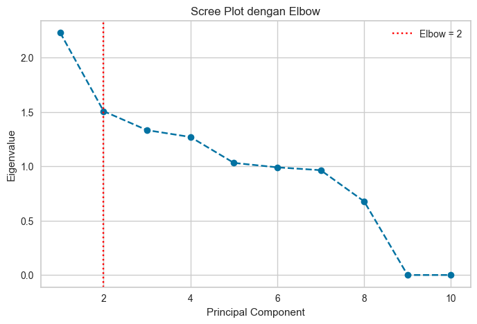

```python
# PCA
pca = PCA(random_state=42)
pca.fit(scaled_df_encoded)
eigenvalues = pca.explained_variance_

# Temukan "elbow" (titik siku)
knee = KneeLocator(
    range(1, len(eigenvalues) + 1),
    eigenvalues,
    curve='convex',
    direction='decreasing'
)

print(f"Titik elbow (komponen optimal): {knee.knee}")

# Visualisasi scree plot dengan elbow
plt.figure(figsize=(8, 5))
plt.plot(range(1, len(eigenvalues) + 1), eigenvalues, marker='o', linestyle='--')
plt.axvline(x=knee.knee, color='red', linestyle=':', label=f'Elbow = {knee.knee}')
plt.title('Scree Plot dengan Elbow')
plt.xlabel('Principal Component')
plt.ylabel('Eigenvalue')
plt.legend()
plt.grid(True)
plt.show()
```

- Plot ini menunjukkan eigenvalue untuk masing-masing komponen utama hasil PCA.
- Titik elbow terlihat di komponen ke-2, artinya hanya 2 komponen utama yang cukup untuk merangkum variasi terbesar dalam data.
- Komponen setelah PC-2 menyumbang lebih sedikit informasi dan bisa diabaikan demi efisiensi

```python
# Membuat objek PCA dengan N komponen optimal
pca = PCA(n_components=knee.knee, random_state=42)

# Melakukan transformasi data
pca_data = pca.fit_transform(scaled_df_encoded)

# Membuat DataFrame hasil PCA

df_pca = pd.DataFrame(data=pca_data, columns=[f'PC-{i}' for i in range(1, knee.knee + 1)])
df_pca
```

|  | PC-1 | PC-2 |
| --- | --- | --- |
| 0 | 1.434094 | 0.001895 |
| 1 | 1.361039 | 0.008980 |
| 2 | 0.344599 | -1.451918 |
| 3 | 0.243474 | -1.320574 |
| 4 | -2.661234 | -1.599413 |
| ... | ... | ... |
| 2507 | -2.735937 | 1.408470 |
| 2508 | 0.317583 | 1.454004 |
| 2509 | 0.259791 | 1.571481 |
| 2510 | 0.318936 | -1.412232 |
| 2511 | -2.605111 | -1.646383 |

2512 rows × 2 columns

### Penentuan Jumlah Klaster Optimal setelah PCA

Setelah proses reduksi dimensi menggunakan PCA, dilakukan kembali evaluasi jumlah cluster optimal dengan dua metode utama:

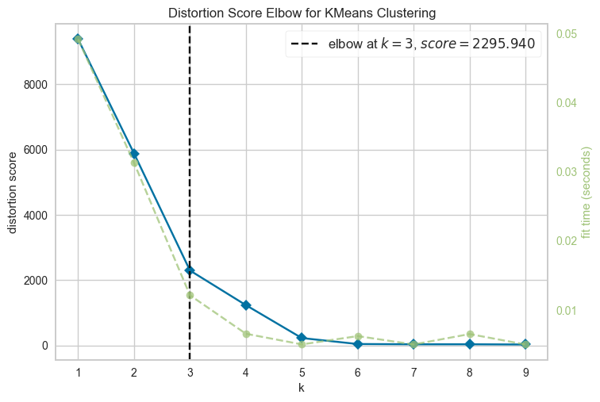

```
Jumlah cluster optimal berdasarkan metode Elbow : 3
```

```python
kmeans = KMeans(random_state=42)
visualizer_pca = KElbowVisualizer(kmeans, k=(1, 10))
visualizer_pca.fit(df_pca)
visualizer_pca.show()
plt.show()
# Menampilkan jumlah cluster optimal yang dipilih oleh KElbowVisualizer
print(f"Jumlah cluster optimal berdasarkan metode Elbow : {visualizer_pca.elbow_value_}")
```

Hasil menunjukkan titik elbow berada di k = 3, artinya penurunan distortion score mulai melambat setelah 3 cluster.

```
Cluster optimal Metode Silhoutte Score Hasil PCA: 6
```

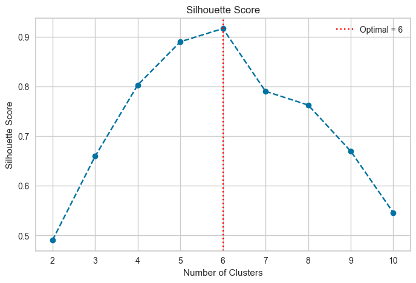

```python
# Penentuan Klaster optimal berdasarkan silhoutte score
silhouette_scores = []
for i in range(2, 11):
    kmeans = KMeans(n_clusters=i, random_state=42)
    kmeans.fit(df_pca)
    silhouette_scores.append(silhouette_score(df_pca, kmeans.labels_))
optimal_clusters_pca = np.argmax(silhouette_scores) + 2  # Karena range mulai dari 2
print(f"Cluster optimal Metode Silhoutte Score Hasil PCA: {optimal_clusters_pca}")

# Visualisasi Silhouette Score
plt.figure(figsize=(8, 5))
plt.plot(range(2, 11), silhouette_scores, marker='o', linestyle='--')
plt.title('Silhouette Score')
plt.xlabel('Number of Clusters')
plt.ylabel('Silhouette Score')
plt.grid(True)
plt.axvline(x=optimal_clusters_pca, color='red', linestyle=':', label=f'Optimal = {optimal_clusters_pca}')
plt.legend()
plt.show()
```

Silhouette Score tertinggi diperoleh pada k = 6.

### Pemodelan KMeans setelah PCA

```python
# K Means Clustering
kmeans_elbow = KMeans(n_clusters=visualizer_pca.elbow_value_, random_state=42)
kmeans_elbow.fit(df_pca)

# Silhouette Score
print(f"Silhouette Score dengan {visualizer_pca.elbow_value_} Klaster: {silhouette_score(df_pca, kmeans_elbow.labels_):.3f}")
```

```
Silhouette Score dengan 3 Klaster: 0.660
```

```python
# K Means Clustering
kmeans_silhouette = KMeans(n_clusters=optimal_clusters_pca, random_state=42)
kmeans_silhouette.fit(df_pca)

# Silhouette Score
print(f"Silhouette Score dengan {optimal_clusters_pca} Klaster: {silhouette_score(df_pca, kmeans_silhouette.labels_):.3f}")
```

```
Silhouette Score dengan 6 Klaster: 0.917
```

Model dengan 6 cluster jauh lebih optimal dibandingkan 3 cluster.

Silhouette Score 0.917 menunjukkan kualitas clustering yang sangat baik pada data hasil PCA.

Maka, model clustering terbaik dari pipeline ini adalah: ➤ KMeans dengan 6 cluster pada data hasil reduksi PCA yang terdiri atas 2 komponen.

## **d. Visualisasi Hasil Clustering**

Setelah menentukan model KMeans terbaik (dengan jumlah cluster optimal = 6 berdasarkan Silhouette Score), langkah selanjutnya adalah menampilkan hasil pengelompokan dalam bentuk visual.

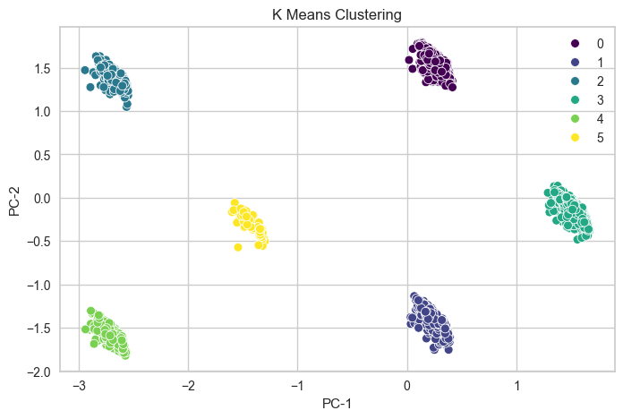

```
Silhouette Score Akhir: 0.917
```

```python
# Visualisasi hasil clustering
plt.figure(figsize=(8, 5))
sns.scatterplot(data=df_pca, x='PC-1', y='PC-2', hue=kmeans_silhouette.labels_, palette='viridis', s=50)
plt.title('K Means Clustering')
plt.grid(True)
plt.show()

# Silhouette Score
print(f"Silhouette Score Akhir: {silhouette_score(df_pca, kmeans_silhouette.labels_):.3f}")
```

Terlihat 6 cluster yang sangat terpisah jelas satu sama lain. Setiap kelompok memiliki bentuk yang kompak dan tidak tumpang tindih, yang menunjukkan bahwa:

- Hasil clustering sangat baik dan bersih.
- Pemisahan antar cluster efektif.

## **e. Analisis dan Interpretasi Hasil Cluster**

Sebelum melakukan interpretasi, perlu dilakukan inverse transformasi pada data agar dapat diinterpretasikan dalam skala aslinya.

```python
# 1. Buat DataFrame dari data yang telah distandardisasi dan tambahkan label cluster
df_normalized = pd.DataFrame(scaled_df_encoded, columns=df_encoded.columns)

## Menambahkan kolom Cluster dari hasil clustering k-means dengan metode Silhouette Score
df_normalized['Cluster'] = kmeans_silhouette.labels_
df_normalized
```

|  | TransactionAmount | CustomerAge | TransactionDuration | LoginAttempts | AccountBalance | TransactionType_Credit | TransactionType_Debit | Channel_ATM | Channel_Branch | Channel_Online | Cluster |
| --- | --- | --- | --- | --- | --- | --- | --- | --- | --- | --- | --- |
| 0 | -0.971275 | 1.423718 | -0.552443 | -0.206794 | -0.000537 | -0.540538 | 0.540538 | 1.419720 | -0.726623 | -0.690491 | 3 |
| 1 | 0.269440 | 1.311287 | 0.305314 | -0.206794 | 2.216472 | -0.540538 | 0.540538 | 1.419720 | -0.726623 | -0.690491 | 3 |
| 2 | -0.586882 | -1.443277 | -0.909842 | -0.206794 | -1.023534 | -0.540538 | 0.540538 | -0.704364 | -0.726623 | 1.448244 | 1 |
| 3 | -0.387456 | -1.049768 | -1.353017 | -0.206794 | 0.885797 | -0.540538 | 0.540538 | -0.704364 | -0.726623 | 1.448244 | 1 |
| 4 | -0.973468 | -1.049768 | 1.120184 | -0.206794 | 0.593589 | 1.850010 | -1.850010 | -0.704364 | -0.726623 | 1.448244 | 4 |
| ... | ... | ... | ... | ... | ... | ... | ... | ... | ... | ... | ... |
| 2507 | 1.913802 | -0.656259 | -0.152156 | -0.206794 | 1.942606 | 1.850010 | -1.850010 | -0.704364 | 1.376230 | -0.690491 | 2 |
| 2508 | -0.157779 | 0.186975 | 0.819969 | -0.206794 | -1.245986 | -0.540538 | 0.540538 | -0.704364 | 1.376230 | -0.690491 | 0 |
| 2509 | -0.921462 | 0.636700 | 0.376794 | -0.206794 | -0.443928 | -0.540538 | 0.540538 | -0.704364 | 1.376230 | -0.690491 | 0 |
| 2510 | -0.382420 | -1.218415 | -1.438793 | -0.206794 | -0.855705 | -0.540538 | 0.540538 | -0.704364 | -0.726623 | 1.448244 | 1 |
| 2511 | -0.186763 | -1.162199 | -0.380892 | -0.206794 | -1.277652 | 1.850010 | -1.850010 | -0.704364 | -0.726623 | 1.448244 | 4 |

2512 rows × 11 columns

```python
# 2. Inverse One-Hot Encoding untuk 'TransactionType' dan 'Channel'
# Identifikasi kolom-kolom one-hot untuk masing-masing fitur kategorikal
transaction_type_cols = [col for col in df_encoded.columns if 'TransactionType' in col]
channel_cols = [col for col in df_encoded.columns if 'Channel' in col]
# Buat kolom kategorikal kembali dengan idxmax
transaction_type = df_encoded[transaction_type_cols].idxmax(axis=1).str.replace('TransactionType_', '')
channel = df_encoded[channel_cols].idxmax(axis=1).str.replace('Channel_', '')
```

### Inverse Data Jika Melakukan Normalisasi/Standardisasi

```python
# Ambil kolom numerik saja dari df_clust (sebelum encoding)
numeric_features = ['TransactionAmount', 'CustomerAge', 'TransactionDuration', 'LoginAttempts', 'AccountBalance']
df_numeric = df_clust[numeric_features]

# Buat scaler baru khusus fitur numerik
scaler_numeric = StandardScaler()
scaled_numeric = scaler_numeric.fit_transform(df_numeric)

# Ambil kembali data aslinya dari scaler
inverse_numeric = scaler_numeric.inverse_transform(scaled_numeric)

# Simpan kembali sebagai DataFrame dengan nama kolom asli
df_inverse_numeric = pd.DataFrame(inverse_numeric, columns=numeric_features).round(2)

# Tambahkan label cluster hasil KMeans
df_inverse_numeric['Cluster'] = kmeans_silhouette.labels_
df_inverse_numeric
```

|  | TransactionAmount | CustomerAge | TransactionDuration | LoginAttempts | AccountBalance | Cluster |
| --- | --- | --- | --- | --- | --- | --- |
| 0 | 14.09 | 70.0 | 81.0 | 1.0 | 5112.21 | 3 |
| 1 | 376.24 | 68.0 | 141.0 | 1.0 | 13758.91 | 3 |
| 2 | 126.29 | 19.0 | 56.0 | 1.0 | 1122.35 | 1 |
| 3 | 184.50 | 26.0 | 25.0 | 1.0 | 8569.06 | 1 |
| 4 | 13.45 | 26.0 | 198.0 | 1.0 | 7429.40 | 4 |
| ... | ... | ... | ... | ... | ... | ... |
| 2507 | 856.21 | 33.0 | 109.0 | 1.0 | 12690.79 | 2 |
| 2508 | 251.54 | 48.0 | 177.0 | 1.0 | 254.75 | 0 |
| 2509 | 28.63 | 56.0 | 146.0 | 1.0 | 3382.91 | 0 |
| 2510 | 185.97 | 23.0 | 19.0 | 1.0 | 1776.91 | 1 |
| 2511 | 243.08 | 24.0 | 93.0 | 1.0 | 131.25 | 4 |

2512 rows × 6 columns

```python
# 3. Gabungkan semua menjadi satu DataFrame
df_final_interpretasi = df_inverse_numeric.copy()
df_final_interpretasi['TransactionType'] = transaction_type
df_final_interpretasi['Channel'] = channel

# 4. Tampilkan hasil
df_final_interpretasi
```

|  | TransactionAmount | CustomerAge | TransactionDuration | LoginAttempts | AccountBalance | Cluster | TransactionType | Channel |
| --- | --- | --- | --- | --- | --- | --- | --- | --- |
| 0 | 14.09 | 70.0 | 81.0 | 1.0 | 5112.21 | 3 | Debit | ATM |
| 1 | 376.24 | 68.0 | 141.0 | 1.0 | 13758.91 | 3 | Debit | ATM |
| 2 | 126.29 | 19.0 | 56.0 | 1.0 | 1122.35 | 1 | Debit | Online |
| 3 | 184.50 | 26.0 | 25.0 | 1.0 | 8569.06 | 1 | Debit | Online |
| 4 | 13.45 | 26.0 | 198.0 | 1.0 | 7429.40 | 4 | Credit | Online |
| ... | ... | ... | ... | ... | ... | ... | ... | ... |
| 2507 | 856.21 | 33.0 | 109.0 | 1.0 | 12690.79 | 2 | Credit | Branch |
| 2508 | 251.54 | 48.0 | 177.0 | 1.0 | 254.75 | 0 | Debit | Branch |
| 2509 | 28.63 | 56.0 | 146.0 | 1.0 | 3382.91 | 0 | Debit | Branch |
| 2510 | 185.97 | 23.0 | 19.0 | 1.0 | 1776.91 | 1 | Debit | Online |
| 2511 | 243.08 | 24.0 | 93.0 | 1.0 | 131.25 | 4 | Credit | Online |

2512 rows × 8 columns

Setelah melakukan clustering, langkah selanjutnya adalah menganalisis karakteristik dari masing-masing cluster berdasarkan fitur yang tersedia.

Berikut adalah **rekomendasi** tahapannya.

1. Analisis karakteristik tiap cluster berdasarkan fitur yang tersedia (misalnya, distribusi nilai dalam cluster).
2. Berikan interpretasi: Apakah hasil clustering sesuai dengan ekspektasi dan logika bisnis? Apakah ada pola tertentu yang bisa dimanfaatkan?

```python
# Grouping untuk analisis statistik deskriptif per klaster
cluster_summary = df_final_interpretasi.groupby('Cluster').agg({
    'TransactionAmount': ['mean', 'median', 'min', 'max'],
    'CustomerAge': ['mean', 'min', 'max'],
    'TransactionDuration': ['mean'],
    'LoginAttempts': lambda x: x.value_counts().index[0],  # mode
    'AccountBalance': ['mean'],
    'TransactionType': lambda x: x.value_counts().index[0],  # mode
    'Channel': lambda x: x.value_counts().index[0],          # mode
})

# Rename columns for clarity
cluster_summary.columns = ['_'.join(col).strip() for col in cluster_summary.columns.values]

# Pembulatan nilai numerik ke 2 desimal (non-kategorikal)
for col in cluster_summary.columns:
    if cluster_summary[col].dtype != 'object':
        cluster_summary[col] = cluster_summary[col].round(2)

cluster_summary
```

| Cluster | TransactionAmount_mean | TransactionAmount_median | TransactionAmount_min | TransactionAmount_max | CustomerAge_mean | CustomerAge_min | CustomerAge_max | TransactionDuration_mean | LoginAttempts_<lambda> | AccountBalance_mean | TransactionType_<lambda> | Channel_<lambda> |
| --- | --- | --- | --- | --- | --- | --- | --- | --- | --- | --- | --- | --- |
| 0 | 276.63 | 186.55 | 0.45 | 1664.33 | 43.93 | 18.0 | 80.0 | 116.81 | 1.0 | 5276.83 | Debit | Branch |
| 1 | 298.90 | 207.65 | 0.26 | 1830.00 | 43.46 | 18.0 | 80.0 | 119.84 | 1.0 | 4850.07 | Debit | Online |
| 2 | 316.75 | 237.99 | 3.30 | 1360.01 | 46.35 | 18.0 | 80.0 | 116.35 | 1.0 | 5018.97 | Credit | Branch |
| 3 | 306.99 | 217.90 | 0.32 | 1919.11 | 45.08 | 18.0 | 80.0 | 121.98 | 1.0 | 5078.58 | Debit | ATM |
| 4 | 293.31 | 199.50 | 3.42 | 1831.02 | 46.67 | 18.0 | 80.0 | 121.39 | 1.0 | 5701.47 | Credit | Online |
| 5 | 315.34 | 252.31 | 2.03 | 1397.59 | 43.74 | 18.0 | 78.0 | 123.21 | 1.0 | 4530.16 | Credit | ATM |

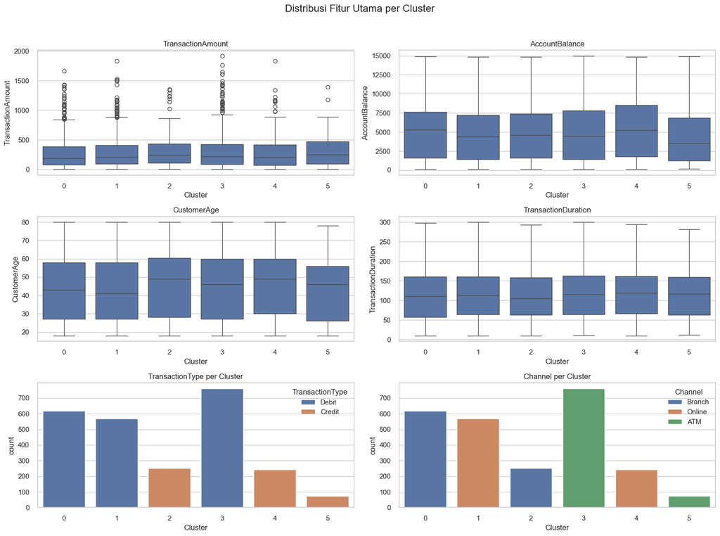

```python
# Buat salinan data untuk visualisasi
df_viz = df_final_interpretasi.copy()

# Set gaya visualisasi
sns.set_theme(style="whitegrid")

# Buat plot boxplot dan distribusi untuk beberapa fitur utama per cluster
fig, axes = plt.subplots(3, 2, figsize=(16, 12))
fig.suptitle("Distribusi Fitur Utama per Cluster", fontsize=16)

# Boxplot TransactionAmount
sns.boxplot(data=df_viz, x='Cluster', y='TransactionAmount', ax=axes[0, 0])
axes[0, 0].set_title("TransactionAmount")

# Boxplot AccountBalance
sns.boxplot(data=df_viz, x='Cluster', y='AccountBalance', ax=axes[0, 1])
axes[0, 1].set_title("AccountBalance")

# Boxplot CustomerAge
sns.boxplot(data=df_viz, x='Cluster', y='CustomerAge', ax=axes[1, 0])
axes[1, 0].set_title("CustomerAge")

# Boxplot TransactionDuration
sns.boxplot(data=df_viz, x='Cluster', y='TransactionDuration', ax=axes[1, 1])
axes[1, 1].set_title("TransactionDuration")

# Countplot TransactionType per cluster
sns.countplot(data=df_viz, x='Cluster', hue='TransactionType', ax=axes[2, 0])
axes[2, 0].set_title("TransactionType per Cluster")

# Countplot Channel per cluster
sns.countplot(data=df_viz, x='Cluster', hue='Channel', ax=axes[2, 1])
axes[2, 1].set_title("Channel per Cluster")

plt.tight_layout(rect=[0, 0, 1, 0.96])
plt.show()
```

1. **Transaction Amount**
- Distribusi mirip antar cluster, banyak outlier.
- **Cluster 2 dan 5**: Median transaksi tertinggi.
- **Cluster 0**: Median transaksi terendah.
2. **Account Balance**
- **Cluster 0**: Saldo tertinggi secara median.
- **Cluster 5**: Saldo terendah.
3. **Customer Age**
- Usia nasabah relatif merata.
- **Cluster 2 dan 4**: Median usia tertinggi → cenderung nasabah lebih tua.
4. **Transaction Duration**
- Durasi transaksi seragam di semua cluster.
- Tidak ada perbedaan signifikan.
5. **Transaction Type**
- **Cluster 0, 1, 3** memiliki jenis transaksi **Debit**.
- **Cluster 2, 4, 5** semuanya bertransaksi secara **Credit**.
- Menunjukkan adanya segmentasi berdasarkan jenis transaksi.
6. **Channel**
- **Cluster 3 dan 5**:semua transaksi lewat **ATM**.
- **Cluster 0 & 2**: semua transaksi lewat **Branch**.
- **Cluster 1 & 4**: semua transaksi lewat **Online**.
- **Cluster 5**: semua transaksi lewat **ATM**.

# Analisis Karakteristik Cluster dari Model KMeans

Berikut adalah analisis karakteristik untuk setiap cluster berdasarkan fitur-fitur utama yang tersedia dalam dataset.

```python
cluster_summary
```

| Cluster | TransactionAmount_mean | TransactionAmount_median | TransactionAmount_min | TransactionAmount_max | CustomerAge_mean | CustomerAge_min | CustomerAge_max | TransactionDuration_mean | LoginAttempts_<lambda> | AccountBalance_mean | TransactionType_<lambda> | Channel_<lambda> |
| --- | --- | --- | --- | --- | --- | --- | --- | --- | --- | --- | --- | --- |
| 0 | 276.63 | 186.55 | 0.45 | 1664.33 | 43.93 | 18.0 | 80.0 | 116.81 | 1.0 | 5276.83 | Debit | Branch |
| 1 | 298.90 | 207.65 | 0.26 | 1830.00 | 43.46 | 18.0 | 80.0 | 119.84 | 1.0 | 4850.07 | Debit | Online |
| 2 | 316.75 | 237.99 | 3.30 | 1360.01 | 46.35 | 18.0 | 80.0 | 116.35 | 1.0 | 5018.97 | Credit | Branch |
| 3 | 306.99 | 217.90 | 0.32 | 1919.11 | 45.08 | 18.0 | 80.0 | 121.98 | 1.0 | 5078.58 | Debit | ATM |
| 4 | 293.31 | 199.50 | 3.42 | 1831.02 | 46.67 | 18.0 | 80.0 | 121.39 | 1.0 | 5701.47 | Credit | Online |
| 5 | 315.34 | 252.31 | 2.03 | 1397.59 | 43.74 | 18.0 | 78.0 | 123.21 | 1.0 | 4530.16 | Credit | ATM |

## Cluster 0:

- **Rata-rata TransactionAmount:** 276,63 satuan uang
- **Rata-rata AccountBalance:** 5.276,83 satuan uang
- **Rata-rata CustomerAge:** 43,93 tahun
- **Jenis Transaksi Dominan:** Debit
- **Channel Dominan:** Branch

**Analisis:**  
Cluster ini terdiri dari nasabah yang berusia menengah dengan saldo yang cukup tinggi. Mereka lebih suka menggunakan transaksi debit di cabang bank. Hal ini menunjukkan mereka mungkin lebih nyaman dengan cara tradisional dalam bertransaksi. Untuk mereka, penawaran layanan eksklusif di cabang atau program loyalitas berbasis layanan offline bisa jadi sangat efektif.

## Cluster 1:

- **Rata-rata TransactionAmount:** 298,90 satuan uang
- **Rata-rata AccountBalance:** 4.850,07 satuan uang
- **Rata-rata CustomerAge:** 43,46 tahun
- **Jenis Transaksi Dominan:** Debit
- **Channel Dominan:** Online

**Analisis:**  
Nasabah di cluster ini cenderung lebih aktif secara digital, dengan saldo yang cukup dan lebih banyak melakukan transaksi online. Ini adalah kelompok yang sangat potensial untuk promosi layanan digital banking, aplikasi mobile, dan layanan e-commerce. Mereka nyaman dengan teknologi dan akan lebih tertarik dengan solusi finansial berbasis digital.

## Cluster 2:

- **Rata-rata TransactionAmount:** 316,75 satuan uang
- **Rata-rata AccountBalance:** 5.018,97 satuan uang
- **Rata-rata CustomerAge:** 46,35 tahun
- **Jenis Transaksi Dominan:** Credit
- **Channel Dominan:** Branch

**Analisis:**  
Pelanggan di cluster ini sedikit lebih tua dan lebih suka menggunakan kartu kredit untuk bertransaksi, dengan preferensi untuk melakukan transaksi di cabang. Mereka memiliki potensi nilai tinggi, namun masih merasa nyaman dengan layanan tradisional. Ini adalah segmen yang bisa diprioritaskan untuk penawaran nasabah prioritas atau layanan personal banking yang lebih eksklusif.

## Cluster 3:

- **Rata-rata TransactionAmount:** 306,99 satuan uang
- **Rata-rata AccountBalance:** 5.078,58 satuan uang
- **Rata-rata CustomerAge:** 45,08 tahun
- **Jenis Transaksi Dominan:** Debit
- **Channel Dominan:** ATM

**Analisis:**  
Meskipun saldo mereka cukup besar, pelanggan di cluster ini lebih suka menggunakan ATM untuk transaksi mereka. Ini menunjukkan bahwa mereka mungkin lebih terbiasa dengan transaksi tunai atau belum sepenuhnya beralih ke layanan digital. Segmen ini bisa menjadi target yang baik untuk edukasi mengenai mobile banking dan layanan digital lainnya.

## Cluster 4:

- **Rata-rata TransactionAmount:** 293,31 satuan uang
- **Rata-rata AccountBalance:** 5.701,47 satuan uang
- **Rata-rata CustomerAge:** 46,67 tahun
- **Jenis Transaksi Dominan:** Credit
- **Channel Dominan:** Online

**Analisis:**  
Pelanggan dalam cluster ini cenderung lebih tua dan memiliki saldo yang cukup tinggi. Mereka aktif melakukan transaksi melalui online dan sering menggunakan kartu kredit. Ini menunjukkan bahwa mereka adalah nasabah premium yang nyaman dengan teknologi. Penawaran produk keuangan eksklusif, seperti kartu kredit premium atau investasi digital, akan sangat menarik bagi mereka.

## Cluster 5:

- **Rata-rata TransactionAmount:** 315,34 satuan uang
- **Rata-rata AccountBalance:** 4.530,16 satuan uang
- **Rata-rata CustomerAge:** 43,74 tahun
- **Jenis Transaksi Dominan:** Credit
- **Channel Dominan:** ATM

**Analisis:**  
Meskipun pelanggan di cluster ini melakukan transaksi besar dan menggunakan kartu kredit, mereka memiliki saldo yang relatif rendah dan lebih suka menggunakan ATM. Hal ini menunjukkan mereka adalah nasabah yang aktif tetapi mungkin membutuhkan penawaran pinjaman mikro atau pembiayaan yang sesuai dengan kebutuhannya. Edukasi tentang pengelolaan keuangan digital bisa sangat membantu untuk segmen ini.

# **7. Mengeksport Data**

Simpan hasilnya ke dalam file CSV.

```python
# Eksprt ke file CSV
df_final_interpretasi.to_csv('Dataset_inisiasi.csv', index=False)
```